# JSM 2025: Estimating the impact of ambient air pollution on overall mortality in the presence of preferential sampling and measurement error using electronic health record data

Authors

Affiliation

Tae Yoon Lee

Quantitative Sciences Unit, Stanford University School of Medicine

Chloe C. Su

Quantitative Sciences Unit, Stanford University School of Medicine

Summer S. Han

Quantitative Sciences Unit, Stanford University School of Medicine

Published

August 2, 2025

Abstract

A network of monitoring sites is often not well-designed for accurately mapping ambient (outdoor) air pollution due to external factors, such as budget constraints and public opinions. As such, naively using point measurements from the monitoring network can lead to biased mapping. This can have profound downstream implications for environmental health studies when this mapping is used to estimate ambient air pollution exposure at participants’ locations. In this talk, we will address this potential bias due to preferential sampling in the design of a monitoring network for estimating the ambient air pollution field in California. We will utilize a recently developed spatio-temporal statistical framework that simultaneously models the air pollution field and monitoring site selection process. Further, we will examine the downstream implications in quantifying the effects of ambient air pollution on 2-year overall mortality among patients diagnosed with lung cancer using electric health record data from Stanford Health Care, an academic medical center. We will employ a Bayesian model to incorporate the measurement error in the air pollution exposure.

# Part I: Data processing

# Import packages

```r
library(tidyverse)
library(lubridate)
library(RSSthemes)
library(sf)
library(sp)
library(ggmap)
library(RAQSAPI)
library(keyring)
library(raqs)
library(gganimate)
library(magick)
library(latex2exp)
```

## API Set-Up for RASQAPI

You need to sign up for API using the following link: https://aqs.epa.gov/aqsweb/documents/data_api.html#signup.

```r
# # For the first-time user, please use the following line
# # keyring::key_set(service = "AQSDatamart", username = "harrytyl@stanford.edu")
# setup the account for access to the EPA data
# store your AQS credentials once per session

datamartAPI_user <- "harrytyl@stanford.edu"
aqs_credentials(username = datamartAPI_user,
                key = key_get(service = "AQSDatamart", username = datamartAPI_user))
set_aqs_user(email = datamartAPI_user,
  key   = key_get(service="AQSDatamart",
                           username=datamartAPI_user))
```

# Import Stanford Health Care (SHC) EHR Data

There are 5,405 patients diagnosed with lung cancer from 2000 to 2021 in this cohort. Summary statistics of this cohort can be found in Su et al. (2025). For this study, we will examine the association between the baseline annual exposure to PM2.5 and 2-year overall mortality.

```r
df_SHC <- read_rds("../data/jsm_shc.rds")
```

# Coordinate Reference System (CRS)

The monitoring site data contain two types of the CRS:

- WGS84 (EPSG:4326)
- NAD83 (EPSG:4296)

- Datum: UTM, Zone 10 (EPSG: 32610) // Zone 10 is used in the Pacific Northwest

```r
utm_crs_km <- st_crs("+proj=utm +zone=10 +ellps=WGS84 +units=km")
```

## Mapping individuals’ mailing addresses

The first step is to import the shape file (i.e., geographic boundaries) for the state of California (CA), which is available on the state government website: https://data.ca.gov/dataset/ca-geographic-boundaries. To make this project computationally feasible, we only examine the counties that contain at least 3% of the cohort size. There are 9 such counties, accounting for more than 80% of the individuals in the SHC cohort.

```r
# read the CA shape file by counties
sf_ca <- st_read("../data/CA_Counties.shp",
                  quiet=T) %>%
  st_transform(., crs = 4326) %>%
  st_transform(crs=utm_crs_km)

# transform the long and lat points to the scale scale of the shape file (crs=4326)
SHC_pts <- df_SHC %>%
  select(longitude,latitude) %>%
  st_as_sf(coords=c("longitude","latitude"),crs=4326) %>%
  st_transform(crs=utm_crs_km)

joined_data <- st_join(SHC_pts,sf_ca)

df_prop <-joined_data %>%
  group_by(COUNTYFP) %>%
  summarise(n=n()) %>%
  ungroup() %>%
  mutate(prop=n/sum(n)*100) %>%
  arrange(-prop)

filter_FP <- df_prop %>%
  filter(prop > 3) %>%
  st_drop_geometry() %>%
  select(COUNTYFP) %>%
  unlist()

df_SHC_geo <- joined_data %>%
  filter(COUNTYFP %in% filter_FP)
```

```r
sf_ca_prop <- sf_ca %>%
  st_join(df_prop %>% select(-COUNTYFP)) %>%
  mutate(prop = ifelse(is.na(prop),0,prop))
```

However, we include one more county, San Benito, to bridge the two selected counties.

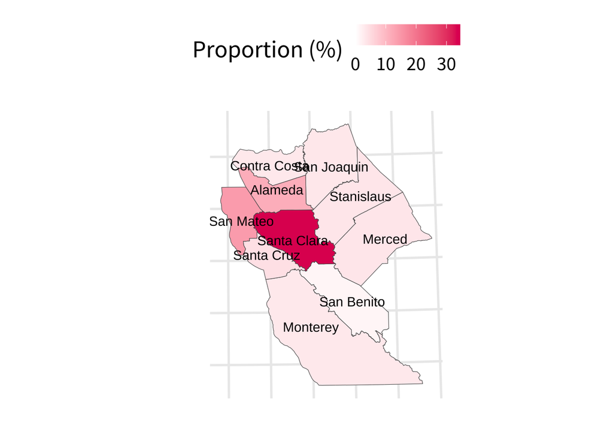

```r
sf_ca_chosen <- sf_ca_prop  %>%
  filter(prop>3 | NAME =="San Benito")

ggplot() +
  geom_sf(data=sf_ca_chosen,aes(fill=prop)) +
  scale_fill_gradient(low='white',high='#E0115F',name="Proportion (%)",limits=c(0,NA))+
  geom_sf_text(data = sf_ca_chosen, aes(label = NAME)) +
  RSSthemes::theme_significance(base_size=20) +
  xlab("") +
  ylab("")+
  theme(legend.position =  "top",
        axis.text.y = element_blank(),
        axis.text.x = element_blank())
```

```r
write_rds(sf_ca_chosen,"../data/ca_border.rds")

df_SHC_chosen <- df_SHC %>%
  filter(CNTYFIPS %in% sf_ca_chosen$COUNTYFP)

write_rds(df_SHC_chosen,"../data/df_SHC_chosen.rds")
```

# Outdoor Air Pollution Monitoring Site for PM2.5

Here we show how the monitoring sites for the chosen counties are added and removed for the period from 1999 to 2021.

```r
# California state code:06 ;  see aqs_states() for details
df_PM25_monitor_CA <- aqs_monitors_by_county(parameter="88101",
                     bdate = as.Date("19990101",format="%Y%m%d"),
                     edate = as.Date("20211231",format="%Y%m%d"),
                     countycode=sf_ca_chosen$COUNTYFP,
                     stateFIPS = "06")  %>%
  select(site_number,open_date,close_date,latitude,longitude) %>%
  mutate(open_date = ymd(open_date),
         close_date = ifelse(is.na(close_date),"2021-12-31",close_date),
         close_date = ymd(close_date)) %>%
  mutate(open_year = year(open_date),
         close_year = year(close_date),
         row_num = row_number()) %>%
  select(site_number,row_num,open_year,close_year,latitude,longitude) %>%
  group_by(row_num) %>%
  group_split() %>%
  lapply(.,function(x){
    data.frame(site_number = x$site_number,
               lat = x$latitude,
               long = x$longitude,
               year = x$open_year:x$close_year)
  }) %>%
  do.call(rbind,.)
write_rds(df_PM25_monitor_CA,"../data/df_PM25_monitor_CA.rds")
df_PM25_monitor_CA <- read_rds("../data/df_PM25_monitor_CA.rds") %>%
  st_as_sf(coords=c("long","lat"),crs=4326) %>%
  st_transform(crs=utm_crs_km) %>%
  filter(year>=1999 & year <= 2021)

monitor_animation <- ggplot() +
  geom_sf(data = sf_ca_chosen,fill=NA) +
    geom_sf(data=df_PM25_monitor_CA,size=5,alpha=0.5) +
  theme_classic() +
  xlab("") +
  ylab("")+
  transition_time(year) +
  ggtitle('Year {frame_time}') +
  theme(text=element_text(size=25),
        plot.title = element_text(hjust=0.5),
        axis.text.y = element_blank(),
        axis.text.x = element_blank()) +
  enter_fade() +
  exit_fade()

num_years = max(df_PM25_monitor_CA$year) - min(df_PM25_monitor_CA$year) + 1

animate(monitor_animation,
        nframes = num_years,
        renderer = magick_renderer(),
        fps = 1,
        height=400,width=600)
anim_save("../figures/CA_monitor_animation.gif",animation=last_animation())
```

[interactive chart not shown]

# Outdoor Air Pollution Data: PM 2.5

We obtain the annual PM2.5 data from the monitoring sites and perform some data cleaning. There are some sites that share the same site number but are not exactly at the same location. For those sites, we use their centroid location instead so that they also share the same location for modeling. Further, we also downscale the latitude and longitude by 10km for computational feasibility for air pollution modeling.

```r
# pm25 : 88101
df_pm25_annual_ca <- annualdata_bystate(param ="88101",
                     bdate = "19990101",
                     edate = "20211231",
                     # county=sf_ca_chosen$COUNTYFP,
                     state = "06")
write_rds(df_pm25_annual_ca,"../data/df_pm25_annual_ca.rds")

df_pm25_annual_ca <- read_rds("../data/df_pm25_annual_ca.rds") %>%
  filter(year >= 1999 & year <=2021) %>%
  filter(county_code %in% sf_ca_chosen$COUNTYFP) %>%
  filter(metric_used=="Daily Mean") %>%
  mutate(unique_key = paste0(county_code,"_",site_number),
         site_number = as.factor(unique_key),
         site_number = as.numeric(site_number))

df_pm25_annual_ca_WGS <- df_pm25_annual_ca %>%
  filter(datum == "WGS84")

df_centroid_WGS <- df_pm25_annual_ca_WGS %>%
  st_as_sf(coords=c("longitude","latitude"),crs=4326) %>%
  st_transform(crs=utm_crs_km)

df_pm25_annual_ca_NAD <- df_pm25_annual_ca %>%
  filter(datum == "NAD83")

df_centroid_NAD <- df_pm25_annual_ca_NAD %>%
  st_as_sf(coords=c("longitude","latitude"),crs=4296) %>%
  st_transform(crs=utm_crs_km)

df_centriod <- rbind(df_centroid_WGS,df_centroid_NAD) %>%
  group_by(site_number) %>%
  group_split() %>%
  lapply(.,function(tmp_df){
    st_union(st_geometry(tmp_df)) %>%
      st_centroid() %>%
      st_coordinates() -> tmp
    c(tmp[1],tmp[2],tmp_df$site_number[1])
  }) %>%
  do.call(rbind,.) %>%
  as.data.frame() %>%
  rename(east=V1,
         north=V2,
         site_number=V3)

df_pm25_annual <- df_pm25_annual_ca %>%
  group_by(site_number,year) %>%
  summarise(n=n(),
            annual_mean = mean(arithmetic_mean),
            annual_sd = mean(standard_deviation)) %>%
  left_join(df_centriod,by="site_number")

write_rds(df_pm25_annual %>%
            select(-n),"../data/df_pm25_annual.rds")

df_pm25_annual <- read_rds("../data/df_pm25_annual.rds")

df_pm25_annual_scaled <- df_pm25_annual %>%
  mutate(north = north / 10,
         east = east / 10)

df_border_scaled <- st_union(sf_ca_chosen) / 10

write_rds(df_pm25_annual_scaled,"../data/df_pm25_annual_scaled.rds")
write_rds(df_border_scaled,"../data/df_border_scaled.rds")
```

What if we monitor the air pollution level systematically using a grid? This is illustrated in the following plots (blue: monitoring sites; black: pseudo-sites).

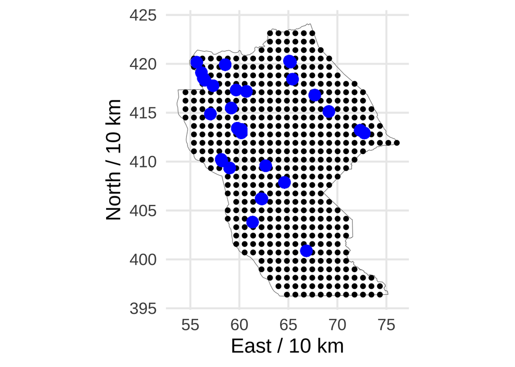

```r
df_border_scaled <- read_rds("../data/df_border_scaled.rds")
df_pm25_annual_scaled <- read_rds("../data/df_pm25_annual_scaled.rds")
st_sample <- st_sample(df_border_scaled,size=500,type='regular') %>% st_as_sf()

ggplot(df_pm25_annual_scaled) +
  geom_sf(data=df_border_scaled,fill=NA) +
  geom_sf(data=st_sample,col='black',size=2,alpha=1) +
    geom_point(aes(x=east,y=north), col='blue',size=5,alpha=1) +
  theme_minimal(base_size=20)+
  xlab("East / 10 km") +
  ylab("North / 10 km")
```

## References

Su, Chloe, Eunji Choi, Mina Satoyoshi, Archana Bhat, Tony Chen, Victoria Ding, Aparajita Khan, et al. 2025. “Oncoshare-Lung: Novel Three-Way Linkage of Neighboring Academic and Community Medical Centers to State Cancer Registry for Lung Cancer.” American Society of Clinical Oncology.